# Partie I - (Données du système Ford GoBike:201902-fordgobike-tripdata)

## Analyse Bivariée

#### Question #6

Existe -t-il une relation entre de la durée des trajets par type de trajet?

#### Visualisation #6

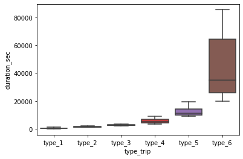

```python
sb.boxplot(data=sous_data, x= 'type_trip', y='duration_sec')
```

#### Observation #6

On remarque bien une forte relation lineaire entre durée de trajet et type de trajet.

#### Question #7

Le type d'utilisateur dépend-t-il du type de trajet?

#### Visualisation #7

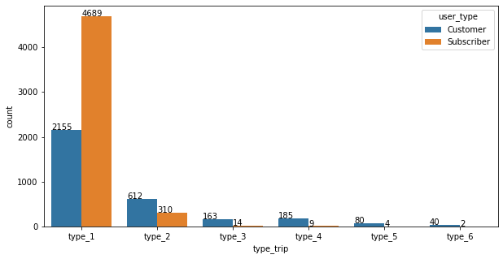

```python
plt.figure(figsize=[10,5])
ax = sb.countplot(data = sous_data, x = 'type_trip', hue = 'user_type');

for p in ax.patches:
    width, height = p.get_width(), p.get_height()
    x, y = p.get_xy()
    ax.annotate((height), (x, y + height))
```

#### Observation #7

Nous observons bien dans ce graphe que, les abonnés effectuent le souvent le trajet du type_1 alors que, les clients effectuent le plus les autres types de trajets.Ainsi, il semble que le fait d'être abonné ou client est influencé par le type du trajet.

#### Question #8

Le type d'utilisateur dépend -t-il du fait qu'un vélo soit du type tout déplacement ou non?

#### Visualisation #8

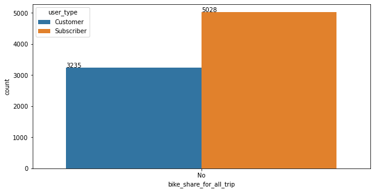

```python
plt.figure(figsize=[10,5])
ax = sb.countplot(data = sous_data, x = 'bike_share_for_all_trip', hue ='user_type')

for p in ax.patches:
    width, height = p.get_width(), p.get_height()
    x, y = p.get_xy()
    ax.annotate((height), (x, y + height))
```

#### Observation #8

Nous constatons que tous ont des vélos qui ne sont pas du type tout déplacement.

#### Question #9

Le fait qu'un utilisateur soit client ou abonné dépend-t-il de la semaine dans laquelle il effectue son trajet?

#### Visualisation #9

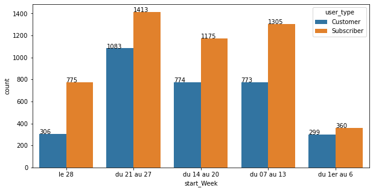

```python
plt.figure(figsize=[10,5])
ax = sb.countplot(data = sous_data, x = 'start_Week', hue ='user_type')

for p in ax.patches:
    width, height = p.get_width(), p.get_height()
    x, y = p.get_xy()
    ax.annotate((height), (x, y + height))
```

#### Observation #9

Dans cette enquête, nous avons observé des relations suivantes:

> Pour les utilisateurs dont le sexe est connu, les variables suivantes sembles avoir une relation entre elles:

[output not shown]

> Pour les utilisateurs dont le sexe n'est mentionné nous avons comme relation:

```
 "type_trip" et "user_type",
 "duration_sec" et "user_type"
```

**Nous pouvons aussi, confirmer le fait connaissant le type de trajet, la relation entre la variable "user_type" et "member_gender" a été renforçée.**

## Conclusion

Nous avons remarqué que:

## Limitation

Tout au long de notre enquête, nous nous sommes heurtés à plusieurs limitations, en autres:

```
a) Les problèmes d'ordre

b) Les problèmes de type des données

c) Le problèmes des données manquantes.
```

## Bibliographie

- https://www.yelp.com/biz/ford-gobike-san-francisco

```python
df_clean.to_csv("SousData_cleaned1.csv", index=False)
sous_data.to_csv("SousData_cleaned2.csv", index=False)
```